# DA5020 – Practicum III

```r
library(tidyverse)
library(psych)
library(Hmisc)
```

Question 1.1 - (10 pts) Load the dataset, directly from the URL, into your R environment. Explore the data, i.e. view the dimensions, the distribution, summary statistics, check for missing values, outliers, correlations etc. (show supporting visualizations). Note: after performing data exploration, if you decide to omit any variables, ensure that you provide an explanation.

```r
forest_fires <- read_csv("http://www.dsi.uminho.pt/~pcortez/forestfires/forestfires.csv")
```

```r
glimpse(forest_fires)
```

```
Rows: 517
Columns: 13
$ X     <dbl> 7, 7, 7, 8, 8, 8, 8, 8, 8, 7, 7, 7, 6, 6, 6, 6, 5, 8, 6, 6, 6, 5, 7, 7, 7, 7, 7, 7, 6, 6, 6, 6, 6, 6, 6, 6, 6, 7, 7, 4...
$ Y     <dbl> 5, 4, 4, 6, 6, 6, 6, 6, 6, 5, 5, 5, 5, 5, 5, 5, 5, 5, 4, 4, 4, 4, 4, 4, 4, 4, 4, 4, 3, 3, 3, 3, 3, 3, 3, 3, 3, 4, 3, 4...
$ month <chr> "mar", "oct", "oct", "mar", "mar", "aug", "aug", "aug", "sep", "sep", "sep", "sep", "aug", "sep", "sep", "sep", "mar",...
$ day   <chr> "fri", "tue", "sat", "fri", "sun", "sun", "mon", "mon", "tue", "sat", "sat", "sat", "fri", "mon", "wed", "fri", "sat",...
$ FFMC  <dbl> 86.2, 90.6, 90.6, 91.7, 89.3, 92.3, 92.3, 91.5, 91.0, 92.5, 92.5, 92.8, 63.5, 90.9, 92.9, 93.3, 91.7, 84.9, 89.2, 86.3...
$ DMC   <dbl> 26.2, 35.4, 43.7, 33.3, 51.3, 85.3, 88.9, 145.4, 129.5, 88.0, 88.0, 73.2, 70.8, 126.5, 133.3, 141.2, 35.8, 32.8, 27.9,...
$ DC    <dbl> 94.3, 669.1, 686.9, 77.5, 102.2, 488.0, 495.6, 608.2, 692.6, 698.6, 698.6, 713.0, 665.3, 686.5, 699.6, 713.9, 80.8, 66...
$ ISI   <dbl> 5.1, 6.7, 6.7, 9.0, 9.6, 14.7, 8.5, 10.7, 7.0, 7.1, 7.1, 22.6, 0.8, 7.0, 9.2, 13.9, 7.8, 3.0, 6.3, 5.1, 7.0, 9.2, 56.1...
$ temp  <dbl> 8.2, 18.0, 14.6, 8.3, 11.4, 22.2, 24.1, 8.0, 13.1, 22.8, 17.8, 19.3, 17.0, 21.3, 26.4, 22.9, 15.1, 16.7, 15.9, 9.3, 18...
$ RH    <dbl> 51, 33, 33, 97, 99, 29, 27, 86, 63, 40, 51, 38, 72, 42, 21, 44, 27, 47, 35, 44, 40, 38, 44, 43, 32, 60, 34, 48, 24, 39...
$ wind  <dbl> 6.7, 0.9, 1.3, 4.0, 1.8, 5.4, 3.1, 2.2, 5.4, 4.0, 7.2, 4.0, 6.7, 2.2, 4.5, 5.4, 5.4, 4.9, 4.0, 4.5, 2.7, 2.7, 4.5, 5.8...
$ rain  <dbl> 0.0, 0.0, 0.0, 0.2, 0.0, 0.0, 0.0, 0.0, 0.0, 0.0, 0.0, 0.0, 0.0, 0.0, 0.0, 0.0, 0.0, 0.0, 0.0, 0.0, 0.0, 0.0, 0.0, 0.0...
$ area  <dbl> 0, 0, 0, 0, 0, 0, 0, 0, 0, 0, 0, 0, 0, 0, 0, 0, 0, 0, 0, 0, 0, 0, 0, 0, 0, 0, 0, 0, 0, 0, 0, 0, 0, 0, 0, 0, 0, 0, 0, 0...
```

```r
describe(forest_fires)
```

```
forest_fires

 13  Variables      517  Observations
-----------------------------------------------------------------------------------------------------------------------------------------
X
       n  missing distinct     Info     Mean      Gmd
     517        0        9    0.982    4.669    2.648

lowest : 1 2 3 4 5, highest: 5 6 7 8 9

Value          1     2     3     4     5     6     7     8     9
Frequency     48    73    55    91    30    86    60    61    13
Proportion 0.093 0.141 0.106 0.176 0.058 0.166 0.116 0.118 0.025
-----------------------------------------------------------------------------------------------------------------------------------------
Y
       n  missing distinct     Info     Mean      Gmd
     517        0        7     0.92      4.3    1.309

lowest : 2 3 4 5 6, highest: 4 5 6 8 9

Value          2     3     4     5     6     8     9
Frequency     44    64   203   125    74     1     6
Proportion 0.085 0.124 0.393 0.242 0.143 0.002 0.012
-----------------------------------------------------------------------------------------------------------------------------------------
month
       n  missing distinct
     517        0       12

lowest : apr aug dec feb jan, highest: mar may nov oct sep

Value        apr   aug   dec   feb   jan   jul   jun   mar   may   nov   oct   sep
Frequency      9   184     9    20     2    32    17    54     2     1    15   172
Proportion 0.017 0.356 0.017 0.039 0.004 0.062 0.033 0.104 0.004 0.002 0.029 0.333
-----------------------------------------------------------------------------------------------------------------------------------------
day
       n  missing distinct
     517        0        7

lowest : fri mon sat sun thu, highest: sat sun thu tue wed

```

[output cut: 53 more lines]

```
Frequency    509     2     1     2     1     1     1
Proportion 0.985 0.004 0.002 0.004 0.002 0.002 0.002
-----------------------------------------------------------------------------------------------------------------------------------------
area
       n  missing distinct     Info     Mean      Gmd      .05      .10      .25      .50      .75      .90      .95
     517        0      251    0.891    12.85     22.7     0.00     0.00     0.00     0.52     6.57    25.26    48.71

lowest :    0.00    0.09    0.17    0.21    0.24, highest:  200.94  212.88  278.53  746.28 1090.84

Value          0    10    20    30    40    50    60    70    80    90   100   110   150   170   190   200   210   280   750  1090
Frequency    366    82    17    15     9     6     4     3     1     2     2     1     1     1     1     2     1     1     1     1
Proportion 0.708 0.159 0.033 0.029 0.017 0.012 0.008 0.006 0.002 0.004 0.004 0.002 0.002 0.002 0.002 0.004 0.002 0.002 0.002 0.002

For the frequency table, variable is rounded to the nearest 10
-----------------------------------------------------------------------------------------------------------------------------------------
```

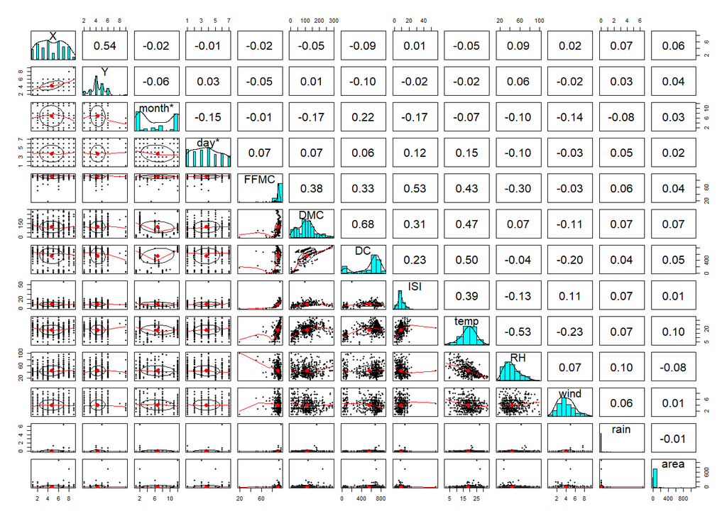

```r
pairs.panels(forest_fires)
```

Since month and day are categorical variables, they should be removed going forward because we cannot calculate (euclidean) distances for categorical values.

**Check for outliers**

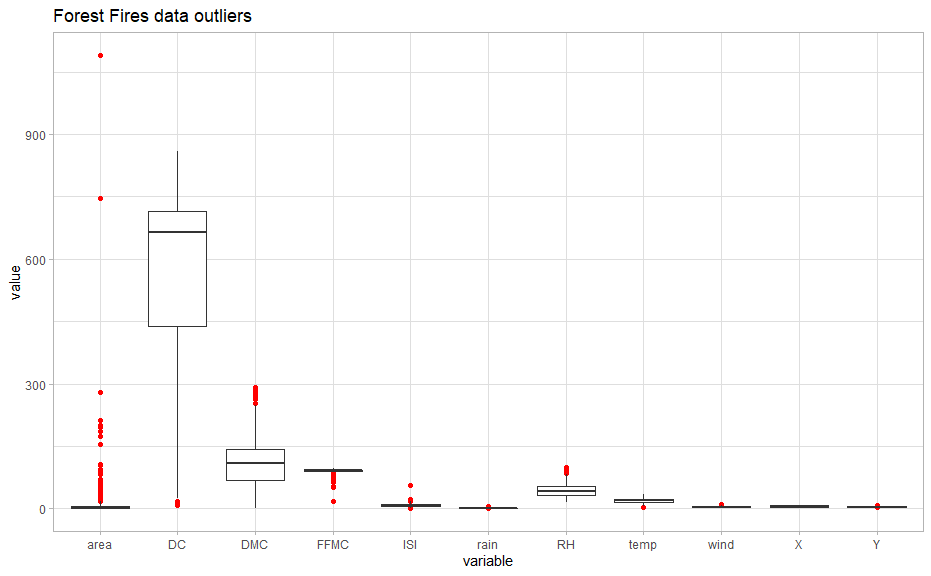

```r
forest_fires %>%
  ## exclude categorical month and day vars
  select(-one_of("month", "day")) %>%
  pivot_longer(1:(ncol(forest_fires)-2),
               names_to = "variable",
               values_to = "value") %>%
  ggplot(aes(x = variable, y = value)) +
  geom_boxplot(outlier.colour = "red") +
  labs(title = "Forest Fires data outliers") +
  theme_light()
```

There appears to be many outliers in `area` and a few in several other variables.

#### Question 1.2 - (10 pts) Create a function called z_score_standardization in which you should define the logic to perform z-score standardization. In a new R chunk, standardize the explanatory variables using the aforementioned function.

```r
z_score_standardization <- function(x) {
  (x - mean(x)) / sd(x)
}
```

```r
forest_fires_norm <- forest_fires %>%

  ## remove categorical data since only numeric
  ## values are valid for euclidean distance calculation
  select(-one_of("month", "day")) %>%
  ## min-max normalization for all columns except area
  mutate_at(c(1:ncol(.)-1), z_score_standardization) %>%
  ## log transform non-zero area values because area
  ## is skewed towards 0
  mutate(area =  log(area + 1))

head(forest_fires_norm)
```

| X | Y | FFMC | DMC | DC | ISI | temp | RH | wind | rain | area |
| --- | --- | --- | --- | --- | --- | --- | --- | --- | --- | --- |
| 1.007337 | 0.5693090 | -0.805179637 | -1.3220451 | -1.8287056 | -0.8601125 | -1.8408572 | 0.4113260 | 1.497164378 | -0.07319742 | 0 |
| 1.007337 | -0.2437649 | -0.008094195 | -1.1783995 | 0.4884179 | -0.5091951 | -0.1531300 | -0.6917863 | -1.740070338 | -0.07319742 | 0 |
| 1.007337 | -0.2437649 | -0.008094195 | -1.0488061 | 0.5601729 | -0.5091951 | -0.7386680 | -0.6917863 | -1.516812772 | -0.07319742 | 0 |
| 1.439531 | 1.3823830 | 0.191177166 | -1.2111882 | -1.8964295 | -0.0047513 | -1.8236355 | 3.2303906 | -0.009824197 | 0.60257159 | 0 |
| 1.439531 | 1.3823830 | -0.243596712 | -0.9301423 | -1.7968593 | 0.1268427 | -1.2897626 | 3.3529586 | -1.237740813 | -0.07319742 | 0 |
| 1.439531 | 1.3823830 | 0.299870636 | -0.3992778 | -0.2416292 | 1.2453920 | 0.5701817 | -0.9369223 | 0.771577287 | -0.07319742 | 0 |

**Check outliers again**

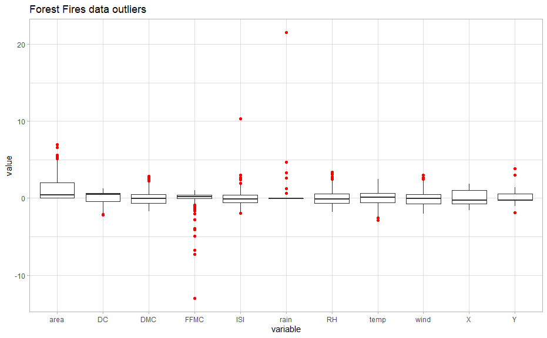

```r
forest_fires_norm %>%
  pivot_longer(1:(ncol(forest_fires_norm)),
               names_to = "variable",
               values_to = "value") %>%
  ggplot(aes(x = variable, y = value)) +
  geom_boxplot(outlier.colour = "red") +
  labs(title = "Forest Fires data outliers") +
  theme_light()
```

Outliers in `area` are significantly reduced, but there are still many in `FFMC`

Pairs panel for normalized data

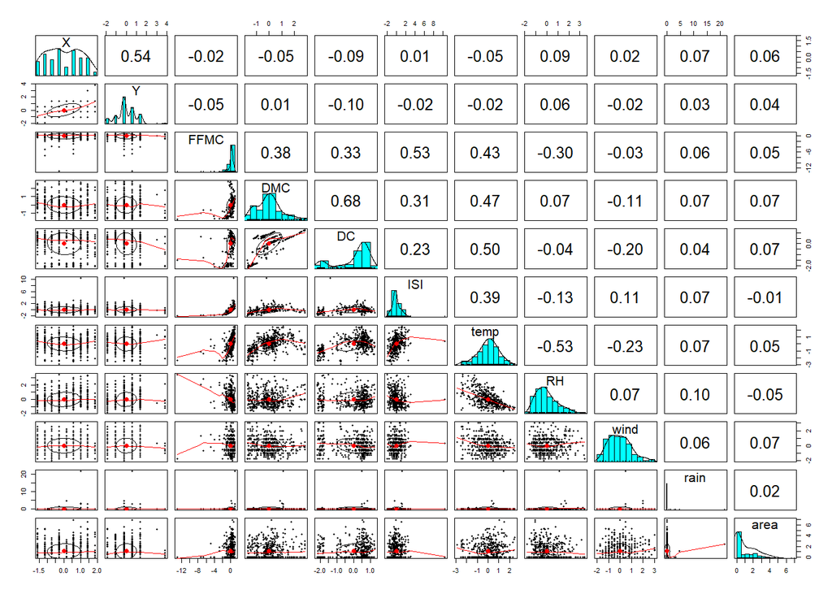

```r
pairs.panels(forest_fires_norm)
```

#### Question 1.3 - (50 pts) Implement the k-NN algorithm in R (do not use an implementation of k-NN from a package). Create a function with the following name and arguments: kNN-regression(data_train, label_train, data_test, k); data_train represents the explanatory variables from the training set and label_trainrepresents the corresponding response variable for each observation in data_train i.e. it will contain the burned area of the forest. The data_test represents the observations from the test set and k is the selected value of k (i.e. the number of neighbors.)

Create functions:

```r
## (euclidean) distance function
dis_fn <- function(a, b) {
  d <- 0
  for (i in 1:length(a)) {
    d <- d + (a[i] - b[i])^2
  }
  return(sqrt(d))
}

## regression function
kNN_regression <- function(k, data_train, label_train, data_test) {

  ## convert train and test data rows to lapply-frienldly list elements
  train_list <-
    data_train %>%
    split(seq(nrow(.)))

  test_list <-
    data_test %>%
    split(seq(nrow(.)))

  ## apply function to each test data row
  lapply(test_list,
         function(x){
           ## the first output are the label (area) values of k neighbors
           labs <- label_train %>% slice(c(
             train_list %>%
               ## apply the distance function to each test row
               lapply(dis_fn, x) %>%
               ## order the output and pull the top k values
               unlist(use.names = FALSE) %>% order() %>% head(k))) %>%
             pull()
           ## get the median value for k nearest neighbors
           labs %>% median()
         }) %>% unlist(use.names = FALSE)
}
```

#### Question 1.4 - Test your k-nn implementation (in a new R chunk): (5 pts) Split the data in #1.2 above into training and testing sets; the percentage split is your decision

```r
set.seed(5020)

## shuffle rows
forest_fires_norm  <- forest_fires_norm[sample(nrow(forest_fires_norm)), ]

## subset top 80%
forest_fires_train <- forest_fires_norm  %>% slice(1:(0.8*n()))
fires_train_data   <- forest_fires_train %>% select(-one_of("area"))
fires_train_labels <- forest_fires_train %>% select(area)

## subset bottom 20%
forest_fires_test  <- forest_fires_norm  %>% slice((0.8*n()) + 1:n())
fires_test_data    <- forest_fires_test  %>% select(-one_of("area"))
fires_test_labels  <- forest_fires_test  %>% select(area)

dim(fires_test_data)
```

```
[1] 104  10
```

```r
dim(fires_train_data)
```

```
[1] 413  10
```

#### Question 1.4 (continued) - (5 pts) Provide the corresponding data from the previous step to the kNN-regression function. Calculate the mean squared error (MSE) between the predictions (i.e the output from the function) and the labels from the test set. Comment on the accuracy of your model’s predictions.

**Long-running block (6 minutes)**

```r
fires_predict <-
  kNN_regression(data_train = fires_train_data,
               label_train  = fires_train_labels,
               data_test    = fires_test_data,
               k            = sqrt(nrow(fires_train_data)))

head(fires_predict)
```

```
[1] 0.0000000 1.0205777 0.0000000 0.9624454 0.3919508 0.9448513
```

**Calculate error and mean squared error**

```r
cbind(fires_test_data, fires_test_labels, fires_predict) %>%
  tibble() %>% mutate(error = area - fires_predict) %>% print() %>%
  summarise(mse = sum(error^2 / length(error)))
```

| X | Y | FFMC | DMC | DC | ISI | temp | RH | wind | rain | area | fires_predict | error |
| --- | --- | --- | --- | --- | --- | --- | --- | --- | --- | --- | --- | --- |
| 0.5751435 | 0.5693090 | 0.191177166 | -1.172154001 | -1.8831266 | -0.26793937 | -0.256460197 | -1.18205837 | 0.492505328 | -0.07319742 | 0.0000000 | 0.00000000 | 0.00000000 |
| -0.7214373 | -0.2437649 | 0.988262609 | 1.096510801 | 0.4968834 | 1.15766268 | 2.309574135 | -1.05949035 | -1.014483247 | -0.07319742 | 2.7523860 | 1.02057770 | 1.73180832 |
| 0.5751435 | -1.0568389 | 0.154946010 | 0.300214140 | 1.0447210 | -0.33373639 | -1.151988957 | 1.33058617 | 0.492505328 | -0.07319742 | 1.9600948 | 0.00000000 | 1.96009478 |
| 1.0073371 | 0.5693090 | 0.064368118 | 0.290845944 | 0.5831507 | -0.44339808 | 0.311856132 | -0.44665022 | -1.014483247 | -0.07319742 | 2.9014216 | 0.96244539 | 1.93897620 |
| 1.8717244 | -0.2437649 | 0.299870636 | -0.293104941 | -0.4266605 | 0.17070741 | 0.673511977 | -1.05949035 | 0.269247762 | -0.07319742 | 0.9669838 | 0.39195077 | 0.57503307 |
| 0.5751435 | 0.5693090 | 0.317986214 | 0.109727487 | 0.4839836 | 0.69708355 | 0.122417356 | -0.69178627 | 1.273906812 | -0.07319742 | 3.0071667 | 0.94485127 | 2.06231538 |
| -1.5858245 | -1.8699129 | 0.064368118 | 0.874796829 | 0.8250216 | -0.42146574 | 1.207384892 | -0.20151416 | -0.233081763 | -0.07319742 | 0.0000000 | 0.00000000 | 0.00000000 |
| 1.4395308 | 1.3823830 | 0.010021384 | 1.299488382 | 0.3832040 | -0.48726276 | -0.463120680 | 1.14673413 | -0.735411288 | -0.07319742 | 2.8524391 | 1.09187262 | 1.76056648 |
| 0.1429499 | -0.2437649 | 0.064368118 | -1.503163594 | -2.1056478 | 0.71901589 | -0.222016783 | -1.05949035 | 0.994834853 | -0.07319742 | 0.0000000 | 0.00000000 | 0.00000000 |
| 0.5751435 | 0.5693090 | -1.040682154 | -1.446954418 | -1.9871311 | -1.32069165 | -2.340286735 | 1.57572222 | 0.269247762 | -0.07319742 | 1.1442228 | 1.30719932 | -0.16297652 |

[output cut: 94 more lines]

| mse |
| --- |
| 2.742824 |

The mean squared error of this model for its prediction of burned forest area is 2.74.

#### Question 1.5 - (15 pts) Provide all values between 3 and 33 inclusive as the value of k (you can increment k by 2).

(5 pts) Create a line chart and plot each value of k (from the previous step) on the x-axis and the corresponding MSE on the y-axis. Explain the chart and determine which value of k is more suitable and why.

**Very long-running block (75 minutes)**

```r
knn_mse <-
  lapply(seq(3, 33, 2),                   ## run the regression algorithm
       kNN_regression,                    ## for k = 3 - 33 with increments of 2
       data_train   = fires_train_data,
       label_train  = fires_train_labels,
       data_test    = fires_test_data) %>%
  lapply(function(x) {
    cbind(x,                              ## create a table with the test data
          fires_test_data,                ## for each value of k
          fires_test_labels) %>%
      tibble() %>%
      mutate(error = area - x) %>%        ## calculate the error for each table
  summarise(
    mse = sum(error^2 / length(error)))
  }) %>% unlist() %>% tibble() %>%        ## create a new table of calculated errors
  rename("mse" = ".") %>%
  mutate(k = seq(3, 33, 2))

knn_mse
```

| mse | k |
| --- | --- |
| 3.567322 | 3 |
| 3.049919 | 5 |
| 3.130876 | 7 |
| 3.012116 | 9 |
| 3.033437 | 11 |
| 2.974803 | 13 |
| 2.977947 | 15 |
| 2.867350 | 17 |
| 2.816544 | 19 |
| 2.729409 | 21 |

[output cut: 6 more lines]

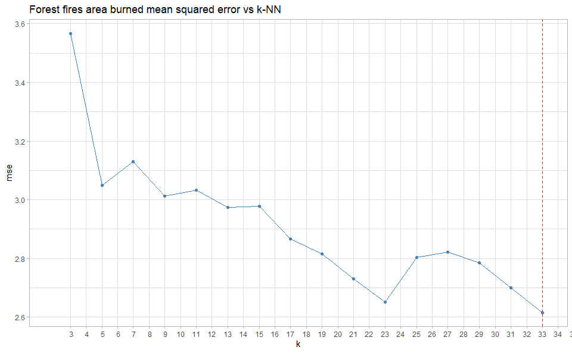

```r
knn_mse %>%
  ggplot(aes(x     = k,
             y     = mse)) +
  geom_point(color = "steelblue") +
  geom_line(color = "steelblue") +
  labs(title = "Forest fires area burned mean squared error vs k-NN") +
  theme_light() +
  geom_vline(xintercept = knn_mse$k[grep(min(knn_mse$mse), knn_mse$mse)],
             linetype   = "dashed",
             color      = "firebrick") +
  scale_x_discrete(limits = seq(3, 36))
```

A K value of 33 is most suitable for this model as it results in the lowest error rate of 2.61.

**How does the MSE change if k-NN is determined using the mode instead of median?**  
We can modify the k-NN function to check:

```r
kNN_regression <- function(k, data_train, label_train, data_test) {
  train_list <-
    data_train %>%
    split(seq(nrow(.)))

  test_list <-
    data_test %>%
    split(seq(nrow(.)))

  lapply(test_list,
         function(x){
           labs <- label_train %>% slice(c(
             train_list %>%
               lapply(dis_fn, x) %>%
               unlist(use.names = FALSE) %>% order() %>% head(k))) %>%
             pull()
           ## determine the mode without using additional packages
           ## (for fun)
           labs[lapply(unique(labs),
                       function(x) { which(x == labs) }) %>%
                  lapply(length) %>% unlist() %>% max()]
         }) %>% unlist(use.names = FALSE)
}
```

Re-run the knn function on the test data  
**(another 75-minute run)**

```r
knn_mse_mode <-
  lapply(seq(3, 33, 2),                     ## run the regression algorithm
         kNN_regression,                    ## for k = 3 - 33 with increments of 2
         data_train   = fires_train_data,
         label_train  = fires_train_labels,
         data_test    = fires_test_data) %>%
  lapply(function(x) {
    cbind(x,                              ## create a table with the test data
          fires_test_data,                ## for each value of k
          fires_test_labels) %>%
      tibble() %>%
      mutate(error = area - x) %>%        ## calculate the error for each table
      summarise(
        mse = sum(error^2 / length(error)))
  }) %>% unlist() %>% tibble() %>%        ## create a new table of calculated errors
  rename("mse" = ".") %>%
  mutate(k = seq(3, 33, 2))

knn_mse_mode
```

| mse | k |
| --- | --- |
| 4.343278 | 3 |
| 3.942707 | 5 |
| 4.385939 | 7 |
| 4.333125 | 9 |
| 3.887108 | 11 |
| 4.433383 | 13 |
| 4.391006 | 15 |
| 4.976331 | 17 |
| 4.264757 | 19 |
| 4.418421 | 21 |

[output cut: 6 more lines]

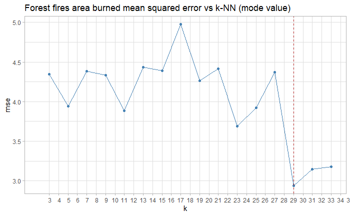

```r
knn_mse_mode %>%
  ggplot(aes(x     = k,
             y     = mse)) +
  geom_point(color = "steelblue") +
  geom_line(color = "steelblue") +
  labs(title = "Forest fires area burned mean squared error vs k-NN (mode value)") +
  theme_light() +
  geom_vline(xintercept = knn_mse_mode$k[grep(min(knn_mse_mode$mse), knn_mse_mode$mse)],
             linetype   = "dashed",
             color      = "firebrick") +
  scale_x_discrete(limits = seq(3, 36))
```

Using the mode, the optimal k value is 29.

What about using the mean k-NN value? **(75-minute run)**

```r
kNN_regression <- function(k, data_train, label_train, data_test) {
  train_list <-
    data_train %>%
    split(seq(nrow(.)))

  test_list <-
    data_test %>%
    split(seq(nrow(.)))

  ## apply function to each test data row
  lapply(test_list,
         function(x){
           ## the first output are the label (area) values of k neighbors
           labs <- label_train %>% slice(c(
             train_list %>%
               ## apply the distance function to each test row
               lapply(dis_fn, x) %>%
               ## order the output and pull the top k values
               unlist(use.names = FALSE) %>% order() %>% head(k))) %>%
             pull()
           ## get the median value for k nearest neighbors
           labs %>% mean()
         }) %>% unlist(use.names = FALSE)
}

knn_mse_mean <-
  lapply(seq(3, 33, 2),                     ## run the regression algorithm
         kNN_regression,                    ## for k = 3 - 33 with increments of 2
         data_train   = fires_train_data,
         label_train  = fires_train_labels,
         data_test    = fires_test_data) %>%
  lapply(function(x) {
    cbind(x,                              ## create a table with the test data
          fires_test_data,                ## for each value of k
          fires_test_labels) %>%
      tibble() %>%
      mutate(error = area - x) %>%        ## calculate the error for each table
      summarise(
        mse = sum(error^2 / length(error)))
  }) %>% unlist() %>% tibble() %>%        ## create a new table of calculated errors
  rename("mse" = ".") %>%
  mutate(k = seq(3, 33, 2))

knn_mse_mean
```

| mse | k |
| --- | --- |
| 2.661387 | 3 |
| 2.467113 | 5 |
| 2.483631 | 7 |
| 2.469554 | 9 |
| 2.346607 | 11 |
| 2.339747 | 13 |
| 2.352207 | 15 |
| 2.304014 | 17 |
| 2.247803 | 19 |
| 2.211447 | 21 |

[output cut: 6 more lines]

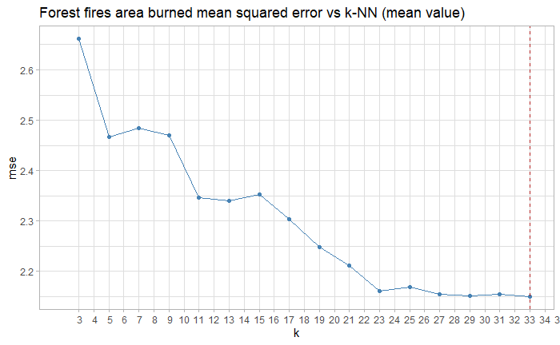

```r
knn_mse_mean %>%
  ggplot(aes(x     = k,
             y     = mse)) +
  geom_point(color = "steelblue") +
  geom_line(color = "steelblue") +
  labs(title = "Forest fires area burned mean squared error vs k-NN (mean value)") +
  theme_light() +
  geom_vline(xintercept = knn_mse_mean$k[grep(min(knn_mse_mean$mse), knn_mse_mean$mse)],
             linetype   = "dashed",
             color      = "firebrick") +
  scale_x_discrete(limits = seq(3, 36))
```

**Let’s see what the three k-NN calculation methods look like together**

| k | mse_median | mse_mode | mse_mean |
| --- | --- | --- | --- |
| 3 | 3.567322 | 4.343278 | 2.661387 |
| 5 | 3.049919 | 3.942707 | 2.467113 |
| 7 | 3.130876 | 4.385939 | 2.483631 |
| 9 | 3.012116 | 4.333125 | 2.469554 |
| 11 | 3.033437 | 3.887108 | 2.346607 |
| 13 | 2.974803 | 4.433383 | 2.339747 |
| 15 | 2.977947 | 4.391006 | 2.352207 |
| 17 | 2.867350 | 4.976331 | 2.304014 |
| 19 | 2.816544 | 4.264757 | 2.247803 |
| 21 | 2.729409 | 4.418421 | 2.211447 |

[output cut: 6 more lines]

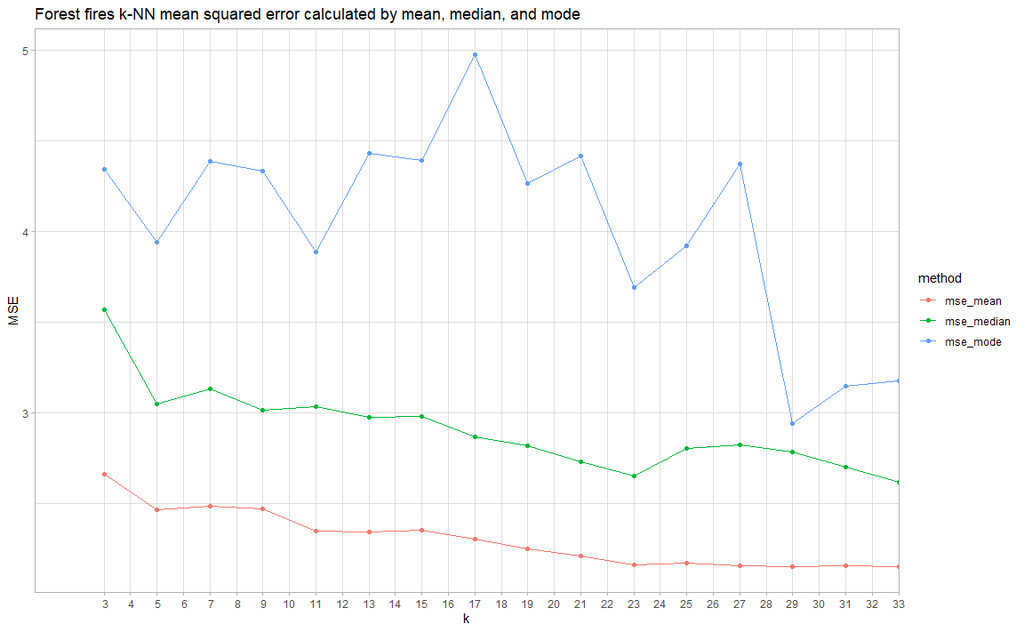

```r
knn_mse %>%
  rename(mse_median = mse) %>%
  left_join(knn_mse_mode) %>%
  rename(mse_mode = mse) %>%
  left_join(knn_mse_mean) %>%
  rename(mse_mean = mse) %>%
  select(k, mse_median,
         mse_mode,
         mse_mean) %>%
  print() %>%
  pivot_longer(cols = c("mse_median", "mse_mode", "mse_mean")) %>%
  ggplot(aes(x = k, y = value, color = name)) +
  geom_point() +
  geom_line(aes(y = value, color = name)) +
  labs(title = "Forest fires k-NN mean squared error calculated by mean, median, and mode",
       y = "MSE",
       color = "method") +
  theme_light() +
  scale_x_discrete(limits = seq(3, 33))
```

Using the mean value of k for k-NN results in a lower mean squared error for all values of k.